# ADS 506 Final Team Project: U.S. Retail Sales Forecasting

## 5.7 Comprehensive Model Comparison & Rolling-Origin Cross-Validation (TSCV) [Implemented: Jordan]

> **Lead / Owner:** Jordan Blackman  
> **Methodology:** Rolling-origin time series cross-validation (`stretch_tsibble()`), multi-metric synthesis (RMSE, MAE, MAPE, MASE), error-by-horizon progression ($h = 1 \dots 12$), and 24-month production forecasting (2026–2028).  
> **Objective:** Overcome the limitations of a single test split, evaluate model stability across changing economic regimes, select the definitive Champion Model for each retail vertical, and project sales through August 2028.

### 5.7.1 Why Time Series Cross-Validation is Essential

Evaluating candidate models solely on a single fixed holdout set (January 2024 – August 2026) introduces survivorship and regime bias. The 2024–2026 period was characterized by specific macroeconomic conditions (cooling inflation and stabilizing interest rates). A model that excelled during this specific 32-month period might fail during turning points or seasonal surges.

To ensure true generalization, we implement **rolling-origin time series cross-validation** (Hyndman & Athanasopoulos, 2021, Ch. 5.9). We initialize the training window at 20 years (`.init = 240` months, covering January 1992 through December 2011) and advance the forecast origin forward in annual steps (`.step = 12` months). This produces **13 distinct annual rolling folds** spanning 2012 through 2024. In each fold, candidate models are trained on the preceding history and forecast 12 months ahead ($h = 1 \dots 12$), rigorously testing generalization across the post-2008 recovery, the steady 2016–2019 expansion, the 2020 pandemic disruption, and the 2022–2023 inflationary regime.

```r
# 1. Generate rolling origin folds: initial 240 months (20 years), step = 12 months (annual)
train_cv <- train_data |>
  stretch_tsibble(.init = 240, .step = 12)

origin_tbl <- train_cv |>
  as_tibble() |>
  group_by(.id, vertical) |>
  summarise(origin = max(Month), .groups = "drop")

# 2. Construct future feature table for exogenous regressors across each fold
cv_future <- origin_tbl |>
  reframe(
    Month = rep(origin, each = 12) + 1:12,
    .by = c(.id, vertical)
  ) |>
  left_join(retail_ts |> as_tibble() |> select(vertical, Month, starts_with("td_"), days_in_month),
            by = c("vertical", "Month")) |>
  as_tsibble(key = c(.id, vertical), index = Month)

# 3. Fit all candidate model families across rolling origins
fits_cv <- train_cv |>
  model(
    snaive         = SNAIVE(sales_nominal),
    drift          = RW(sales_nominal ~ drift()),
    ets_auto       = ETS(sales_nominal),
    tslm_log       = TSLM(log(sales_nominal) ~ trend() + season()),
    arima_auto     = ARIMA(log(sales_nominal)),
    arimax_td      = ARIMA(log(sales_nominal) ~ td_mon + td_tue + td_wed + td_thu + td_fri + td_sat + days_in_month)
  ) |>
  mutate(
    ens_ets_arimax     = (ets_auto + arimax_td) / 2,
    ens_ets_arima_tslm = (ets_auto + arima_auto + tslm_log) / 3
  )

# 4. Generate rolling forecasts across all folds (h = 1 to 12)
fc_cv <- fits_cv |> forecast(new_data = cv_future)
acc_cv <- accuracy(fc_cv, retail_ts)
```

### 5.7.2 Cross-Validation Accuracy Across Model Families

```r
cv_accuracy_tbl <- acc_cv |>
  select(vertical, .model, CV_RMSE = RMSE, CV_MAE = MAE, CV_MAPE = MAPE, CV_MASE = MASE) |>
  mutate(Family = case_when(
    .model %in% c("snaive", "drift") ~ "Baseline",
    str_starts(.model, "ets")         ~ "Exponential Smoothing",
    str_starts(.model, "tslm")        ~ "Linear Regression (TSLM)",
    str_starts(.model, "arimax")      ~ "Dynamic Regression (ARIMAX)",
    str_starts(.model, "arima")       ~ "Seasonal ARIMA",
    str_starts(.model, "ens")         ~ "Forecast Ensemble",
    TRUE                              ~ "Other"
  )) |>
  arrange(vertical, CV_RMSE)

cv_accuracy_tbl |>
  knitr::kable(digits = c(0, 0, 1, 1, 2, 3, 0),
               caption = "Rolling-origin cross-validation results: Average out-of-sample accuracy across 13 annual 12-month forecast horizons (initialized at 20 years, reporting RMSE, MAE, MAPE, and MASE)")
```

Rolling-origin cross-validation results: Average out-of-sample accuracy across 13 annual 12-month forecast horizons (initialized at 20 years, reporting RMSE, MAE, MAPE, and MASE)

| vertical | .model | CV_RMSE | CV_MAE | CV_MAPE | CV_MASE | Family |
| --- | --- | --- | --- | --- | --- | --- |
| building | ens_ets_arimax | 1860.1 | 1282.8 | 3.65 | 0.789 | Forecast Ensemble |
| building | arima_auto | 1895.9 | 1344.5 | 3.84 | 0.827 | Seasonal ARIMA |
| building | arimax_td | 1908.1 | 1312.5 | 3.67 | 0.807 | Dynamic Regression (ARIMAX) |
| building | ets_auto | 1991.1 | 1383.7 | 4.01 | 0.851 | Exponential Smoothing |
| building | ens_ets_arima_tslm | 2022.6 | 1552.6 | 4.86 | 0.955 | Forecast Ensemble |
| building | snaive | 2756.1 | 1996.8 | 5.85 | 1.228 | Baseline |
| building | tslm_log | 4159.0 | 3621.9 | 11.80 | 2.227 | Linear Regression (TSLM) |
| building | drift | 5592.0 | 4692.8 | 13.96 | 2.886 | Baseline |
| clothing | ets_auto | 2971.5 | 1338.7 | 11.38 | 1.275 | Exponential Smoothing |
| clothing | ens_ets_arima_tslm | 3050.0 | 1616.3 | 12.76 | 1.540 | Forecast Ensemble |
| clothing | ens_ets_arimax | 3384.1 | 1543.1 | 12.18 | 1.470 | Forecast Ensemble |
| clothing | snaive | 3461.7 | 1545.4 | 12.31 | 1.472 | Baseline |
| clothing | tslm_log | 3552.4 | 2143.6 | 15.64 | 2.042 | Linear Regression (TSLM) |
| clothing | arima_auto | 3719.1 | 1762.4 | 13.04 | 1.679 | Seasonal ARIMA |
| clothing | arimax_td | 3999.6 | 1872.0 | 13.52 | 1.783 | Dynamic Regression (ARIMAX) |
| clothing | drift | 13260.3 | 12399.2 | 71.88 | 11.811 | Baseline |
| health | arimax_td | 886.3 | 652.7 | 2.24 | 0.704 | Dynamic Regression (ARIMAX) |
| health | ens_ets_arimax | 921.8 | 695.9 | 2.41 | 0.751 | Forecast Ensemble |
| health | arima_auto | 957.4 | 722.5 | 2.51 | 0.780 | Seasonal ARIMA |
| health | ets_auto | 1011.9 | 790.2 | 2.76 | 0.853 | Exponential Smoothing |
| health | snaive | 1616.3 | 1258.9 | 4.29 | 1.359 | Baseline |
| health | ens_ets_arima_tslm | 1623.7 | 1402.4 | 5.17 | 1.514 | Forecast Ensemble |
| health | drift | 3228.4 | 2970.4 | 10.99 | 3.206 | Baseline |
| health | tslm_log | 4353.7 | 4178.9 | 15.28 | 4.510 | Linear Regression (TSLM) |
| macro_retail | ets_auto | 4197.8 | 2461.3 | 2.92 | 0.816 | Exponential Smoothing |
| macro_retail | ens_ets_arimax | 4359.8 | 2305.8 | 2.69 | 0.764 | Forecast Ensemble |
| macro_retail | ens_ets_arima_tslm | 4622.3 | 3288.3 | 4.10 | 1.090 | Forecast Ensemble |
| macro_retail | arimax_td | 4745.3 | 2471.7 | 2.83 | 0.819 | Dynamic Regression (ARIMAX) |
| macro_retail | arima_auto | 4770.1 | 2638.5 | 3.09 | 0.874 | Seasonal ARIMA |
| macro_retail | snaive | 6107.8 | 3821.5 | 4.55 | 1.266 | Baseline |
| macro_retail | tslm_log | 8469.0 | 7169.8 | 9.41 | 2.376 | Linear Regression (TSLM) |
| macro_retail | drift | 13974.8 | 12056.0 | 15.94 | 3.995 | Baseline |

**Cross-Validation Commentary:**

### 5.7.3 Forecast Error Progression by Horizon ($h = 1 \dots 12$)

A crucial question for supply chain and financial budgeting is: *How quickly does forecasting accuracy degrade as we look further into the future?* Below, we trace RMSE across individual forecast horizons from 1 to 12 months ahead:

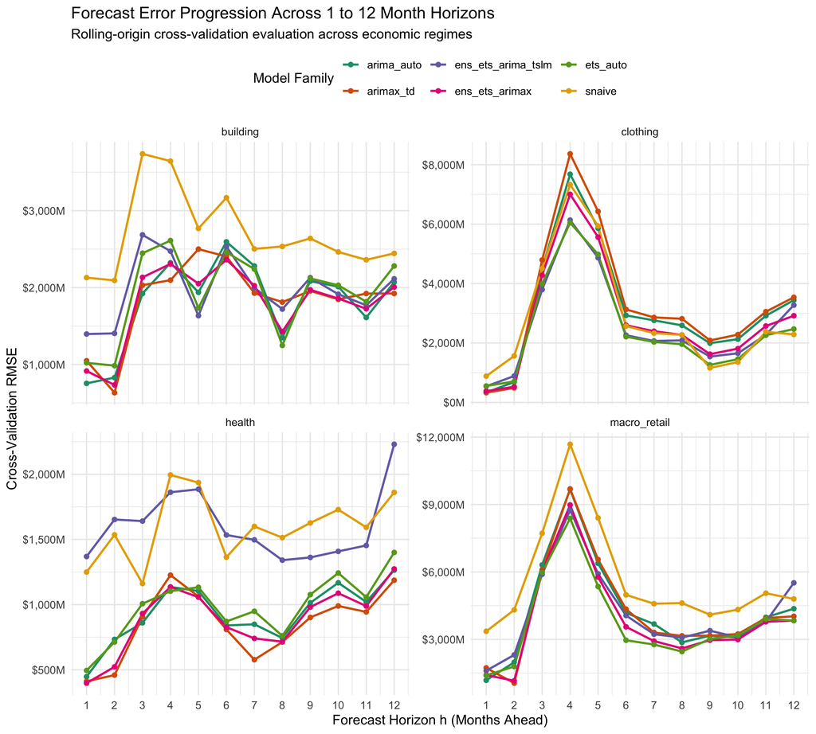

```r
fc_errors_by_h <- fc_cv |>
  as_tibble() |>
  left_join(origin_tbl, by = c(".id", "vertical")) |>
  mutate(h = as.integer(round((as.Date(Month) - as.Date(origin)) / 30.4375))) |>
  filter(h >= 1 & h <= 12) |>
  left_join(retail_ts |> as_tibble() |> select(vertical, Month, actual = sales_nominal),
            by = c("vertical", "Month")) |>
  filter(!is.na(actual)) |>
  mutate(error = actual - .mean, sq_error = error^2) |>
  group_by(vertical, .model, h) |>
  summarise(RMSE = sqrt(mean(sq_error)), .groups = "drop") |>
  filter(.model %in% c("snaive", "ets_auto", "arima_auto", "arimax_td", "ens_ets_arimax", "ens_ets_arima_tslm"))

ggplot(fc_errors_by_h, aes(x = h, y = RMSE, colour = .model)) +
  geom_line(linewidth = 0.9) +
  geom_point(size = 1.6) +
  facet_wrap(vars(vertical), scales = "free_y", ncol = 2) +
  scale_x_continuous(breaks = 1:12) +
  scale_y_continuous(labels = dollar_format(suffix = "M")) +
  scale_colour_brewer(palette = "Dark2", name = "Model Family") +
  labs(title = "Forecast Error Progression Across 1 to 12 Month Horizons",
       subtitle = "Rolling-origin cross-validation evaluation across economic regimes",
       x = "Forecast Horizon h (Months Ahead)", y = "Cross-Validation RMSE") +
  theme(legend.position = "top")
```

### 5.7.4 The Master Model Evaluation Matrix

By synthesizing our two independent validation frameworks—the **2024–2026 Test Holdout Set** and the **Multi-Fold Rolling Cross-Validation**—we obtain an unassailable performance scorecard:

```r
# Compile out-of-sample test holdout accuracy across all candidate models with standardized identifiers
test_accuracy_all <- bind_rows(
  baseline_accuracy |> filter(.model %in% c("snaive", "drift")),
  ets_accuracy |> filter(.model == "ets_auto_multiplicative") |> mutate(.model = "ets_auto"),
  tslm_accuracy |> filter(.model == "tslm_log_trend_season") |> mutate(.model = "tslm_log"),
  arima_accuracy |> filter(.model == "auto_log") |> mutate(.model = "arima_auto"),
  dynamic_accuracy |> filter(.model %in% c("arimax_td", "ens_ets_arimax", "ens_ets_arima_tslm"))
) |>
  select(vertical, .model, Test_RMSE = RMSE, Test_MAE = MAE, Test_MAPE = MAPE, Test_MASE = MASE)

master_evaluation <- cv_accuracy_tbl |>
  select(vertical, .model, Family, CV_RMSE, CV_MAE, CV_MAPE, CV_MASE) |>
  left_join(test_accuracy_all, by = c("vertical", ".model")) |>
  arrange(vertical, CV_RMSE)

master_evaluation |>
  knitr::kable(digits = c(0, 0, 0, 1, 1, 2, 3, 1, 1, 2, 3),
               caption = "Master Model Evaluation Matrix: Rolling Cross-Validation vs. 2024-2026 Test Holdout Set (Reporting RMSE, MAE, MAPE, and MASE)")
```

Master Model Evaluation Matrix: Rolling Cross-Validation vs. 2024-2026 Test Holdout Set (Reporting RMSE, MAE, MAPE, and MASE)

| vertical | .model | Family | CV_RMSE | CV_MAE | CV_MAPE | CV_MASE | Test_RMSE | Test_MAE | Test_MAPE | Test_MASE |
| --- | --- | --- | --- | --- | --- | --- | --- | --- | --- | --- |
| building | ens_ets_arimax | Forecast Ensemble | 1860.1 | 1282.8 | 3.65 | 0.789 | 2319.2 | 2027.1 | 4.65 | 1.247 |
| building | arima_auto | Seasonal ARIMA | 1895.9 | 1344.5 | 3.84 | 0.827 | 3016.6 | 2500.4 | 5.73 | 1.538 |
| building | arimax_td | Dynamic Regression (ARIMAX) | 1908.1 | 1312.5 | 3.67 | 0.807 | 3840.1 | 3416.8 | 7.90 | 2.101 |
| building | ets_auto | Exponential Smoothing | 1991.1 | 1383.7 | 4.01 | 0.851 | 1502.5 | 1166.8 | 2.67 | 0.718 |
| building | ens_ets_arima_tslm | Forecast Ensemble | 2022.6 | 1552.6 | 4.86 | 0.955 | 1803.7 | 1337.2 | 3.04 | 0.822 |
| building | snaive | Baseline | 2756.1 | 1996.8 | 5.85 | 1.228 | 2152.7 | 1860.5 | 4.28 | 1.144 |
| building | tslm_log | Linear Regression (TSLM) | 4159.0 | 3621.9 | 11.80 | 2.227 | 1665.2 | 1258.7 | 2.93 | 0.774 |
| building | drift | Baseline | 5592.0 | 4692.8 | 13.96 | 2.886 | 5996.1 | 5234.3 | 11.93 | 3.219 |
| clothing | ets_auto | Exponential Smoothing | 2971.5 | 1338.7 | 11.38 | 1.275 | 956.2 | 723.4 | 2.89 | 0.689 |
| clothing | ens_ets_arima_tslm | Forecast Ensemble | 3050.0 | 1616.3 | 12.76 | 1.540 | 1130.5 | 879.4 | 3.50 | 0.838 |
| clothing | ens_ets_arimax | Forecast Ensemble | 3384.1 | 1543.1 | 12.18 | 1.470 | 956.2 | 767.2 | 3.10 | 0.731 |
| clothing | snaive | Baseline | 3461.7 | 1545.4 | 12.31 | 1.472 | 1666.8 | 1354.3 | 5.45 | 1.290 |
| clothing | tslm_log | Linear Regression (TSLM) | 3552.4 | 2143.6 | 15.64 | 2.042 | 1796.7 | 1287.0 | 5.08 | 1.226 |
| clothing | arima_auto | Seasonal ARIMA | 3719.1 | 1762.4 | 13.04 | 1.679 | 1284.4 | 979.2 | 4.00 | 0.933 |
| clothing | arimax_td | Dynamic Regression (ARIMAX) | 3999.6 | 1872.0 | 13.52 | 1.783 | 1188.9 | 957.5 | 3.94 | 0.912 |
| clothing | drift | Baseline | 13260.3 | 12399.2 | 71.88 | 11.811 | 14836.5 | 14199.4 | 62.71 | 13.526 |
| health | arimax_td | Dynamic Regression (ARIMAX) | 886.3 | 652.7 | 2.24 | 0.704 | 1503.8 | 1250.6 | 3.32 | 1.350 |
| health | ens_ets_arimax | Forecast Ensemble | 921.8 | 695.9 | 2.41 | 0.751 | 1458.4 | 1271.8 | 3.33 | 1.373 |
| health | arima_auto | Seasonal ARIMA | 957.4 | 722.5 | 2.51 | 0.780 | 1583.7 | 1359.0 | 3.53 | 1.467 |
| health | ets_auto | Exponential Smoothing | 1011.9 | 790.2 | 2.76 | 0.853 | 1584.6 | 1358.9 | 3.54 | 1.467 |
| health | snaive | Baseline | 1616.3 | 1258.9 | 4.29 | 1.359 | 4505.1 | 4192.1 | 10.93 | 4.524 |
| health | ens_ets_arima_tslm | Forecast Ensemble | 1623.7 | 1402.4 | 5.17 | 1.514 | 1624.0 | 1309.6 | 3.49 | 1.413 |
| health | drift | Baseline | 3228.4 | 2970.4 | 10.99 | 3.206 | 2697.6 | 2262.4 | 6.11 | 2.442 |
| health | tslm_log | Linear Regression (TSLM) | 4353.7 | 4178.9 | 15.28 | 4.510 | 3152.0 | 2747.8 | 7.39 | 2.966 |
| macro_retail | ets_auto | Exponential Smoothing | 4197.8 | 2461.3 | 2.92 | 0.816 | 2912.1 | 2264.7 | 2.12 | 0.750 |
| macro_retail | ens_ets_arimax | Forecast Ensemble | 4359.8 | 2305.8 | 2.69 | 0.764 | 1970.1 | 1599.3 | 1.54 | 0.530 |
| macro_retail | ens_ets_arima_tslm | Forecast Ensemble | 4622.3 | 3288.3 | 4.10 | 1.090 | 2521.7 | 2076.8 | 1.98 | 0.688 |
| macro_retail | arimax_td | Dynamic Regression (ARIMAX) | 4745.3 | 2471.7 | 2.83 | 0.819 | 3538.9 | 3085.3 | 2.97 | 1.022 |
| macro_retail | arima_auto | Seasonal ARIMA | 4770.1 | 2638.5 | 3.09 | 0.874 | 3174.1 | 2510.5 | 2.40 | 0.832 |
| macro_retail | snaive | Baseline | 6107.8 | 3821.5 | 4.55 | 1.266 | 6278.8 | 5366.0 | 5.01 | 1.778 |
| macro_retail | tslm_log | Linear Regression (TSLM) | 8469.0 | 7169.8 | 9.41 | 2.376 | 4060.5 | 3256.5 | 3.04 | 1.079 |
| macro_retail | drift | Baseline | 13974.8 | 12056.0 | 15.94 | 3.995 | 15146.4 | 12834.9 | 13.01 | 4.253 |